# How Do Hurricanes, Wildfires, and Floods Affect Human Welfare and Economics in the United States?

Kaya Williams, Akillesh Suresh, Alyssa Girard

2025-11-21

### Takes a while to run because of a large dataset but it works.

## Data Sources

### Natural Disasters: Our World in Data

- Our first data source is from Our World in Data’s Natural Disasters dataset
- It contains data from multiple types of disasters and impacts (e.g., deaths, injuries, homeless, et cetera) and the year the disaster occurred.
- We believe this data source is valid, because Our World In Data gets their data from valid sources, listed on their website as “international institutions and statistical agencies, such as the OECD, the World Bank, the WHO, and UN institutions, specialized institutes and think tanks, such as the Peace Research Institute Oslo (PRIO), academic research articles, such as Bourguignon & Morrison (2002) ’Inequality Among World Citizens: 1820-1992’ in the American Economic Review, and official data from government sources.”
- Link: https://ourworldindata.org/natural-disasters#explore-data-on-natural-disasters

### Losses from Natural Disasters: Federal Reserve Bank of New York

- Our second data source is the Federal Reserve Bank of New York’s Losses from Natural Disasters, which describes the direct damages from natural disasters across the United States by county.
- We believe this data source is valid because it is from a federal resource, specifically the Federal Reserve Bank of New York.
- Link: https://www.newyorkfed.org/research/policy/natural-disaster-losses/#interactive

### A Weekly Influenza Surveillance Report: CDC

- Our third data source is the CDC’s Weekly Influenze Surveillance Report, which tracks the level of visits for respiratory illness.
- We believe this source is valid because it comes directly from the Center of Disease Control, a government organization.
- Link: https://gis.cdc.gov/grasp/fluview/main.html

## Evaluating Our Proposal Expectations

### How much do natural disasters affect the U.S. economy?

We asked the question, “How much do natural disasters affect the U.S. economy?” Based on our research and previous research, we predicted that the disasters that created the most property damage were floods, hurricanes, and tornadoes. We predicted that these disasters would create large financial losses because they are likely to destroy homes, infrastructure, and public utilities; thus, requiring millions of dollars in recovery to repair. We anticipated that wildfires could impact the economy considerably in some areas, but that the overall loss would be lower than that of storms and flooding. Overall, we predicted that the most severe weather-related disasters would create large long-term burdens on the assigned regions.

### Which U.S. regions experience the highest economic losses from natural disasters?

Initially, we asked, “What regions have been most affected by natural disasters?” After some deliberation, we concluded that our question was too vague, as the term “affected” could refer to physical damage to structures, economic losses, frequency of event occurrence, public health outcomes, or other types of impact. Referring to our Federal Reserve dataset, we revised our original question, in order to focus specifically on economic losses, something the Federal Reserve dataset measured annually on a consistent basis across counties in the United States. Once we reframed our question to focus on economic loss, the results of our analysis confirmed our original hypothesis that the Gulf Coast states had the greatest economic losses due the frequency of hurricanes and flooding - with Texas, Louisiana, Mississippi, Alabama, and Florida experiencing the highest cumulative economic damages. Elevated economic losses also appear along the Atlantic coastline, in some comparison with California on the West Coast, while much of the midwest and northern interior appeared with much reduced total economic losses. Overall, our revised question allowed us to more definitively conclude that coastal areas, especially Gulf and Atlantic coastal regions, face the greatest economic vulnerability to natural disasters.

## Preliminary Charts

### How do rates of respiratory symptoms change after natural disasters?

```r
nc<- read_csv(here("data/OverallCounts_tidy.csv"))


nc<- nc[31:52,]

nc <- nc %>%
  rename(`Covid_like_illness` = "COVID-like Illness",
         `RSV_like_illness` = "RSV-like Illness") %>%
  separate(Week_of, c("Date","Year"), sep = ',') %>%
  mutate(total = Covid_like_illness + RSV_like_illness + Influenza) %>%
  select(-2)

nc$Date <- as.character(nc$Date)
nc$Date <- factor(nc$Date, levels=unique(nc$Date))
```

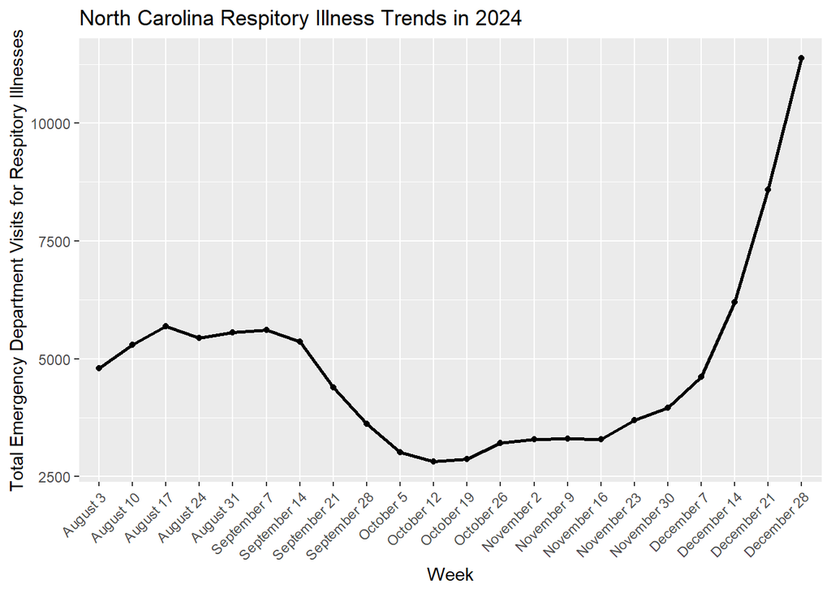

```r
helene_illness <- ggplot(data = nc, aes(x = Date, y = total))+
  geom_line(linewidth = 1, na.rm = T, aes(group=1))+
  geom_point()+
  theme(axis.text.x = element_text(angle = 45, hjust=1))+
  labs(x = "Week",
       y = "Total Emergency Department Visits for Respitory Illnesses",
       title = "North Carolina Respitory Illness Trends in 2024")

helene_illness
```

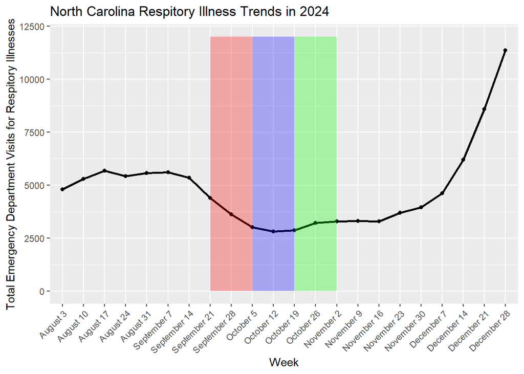

```r
p1<- helene_illness + annotate("rect", xmin = "September 21", xmax = "October 5", ymin = 0, ymax = 12000,
             alpha = 0.3, fill = "red") +
  annotate("rect", xmin = "October 5", xmax = "October 19", ymin = 0, ymax = 12000,
             alpha = 0.3, fill = "blue")+
  annotate("rect", xmin = "October 19", xmax = "November 2", ymin = 0, ymax = 12000,
             alpha = 0.3, fill = "green")

p1
```

The relationship this graph investigates is the relationship between total emergency department visits in North Carolina for respiratory illnesses and the Weeks leading up to and following a natural disaster. The highlighted portion in red is the two weeks during which Hurricane Helene devastated North Carolina. The blue represents two weeks where there are recovery and emergency services in the area. The green represents the time frame after the two-week recovery period, when respiratory illnesses start to incubate. This is when symptoms will start to show, and people will be getting tested for illness. This portion shows a slight uptick in respiratory illnesses following the hurricane.

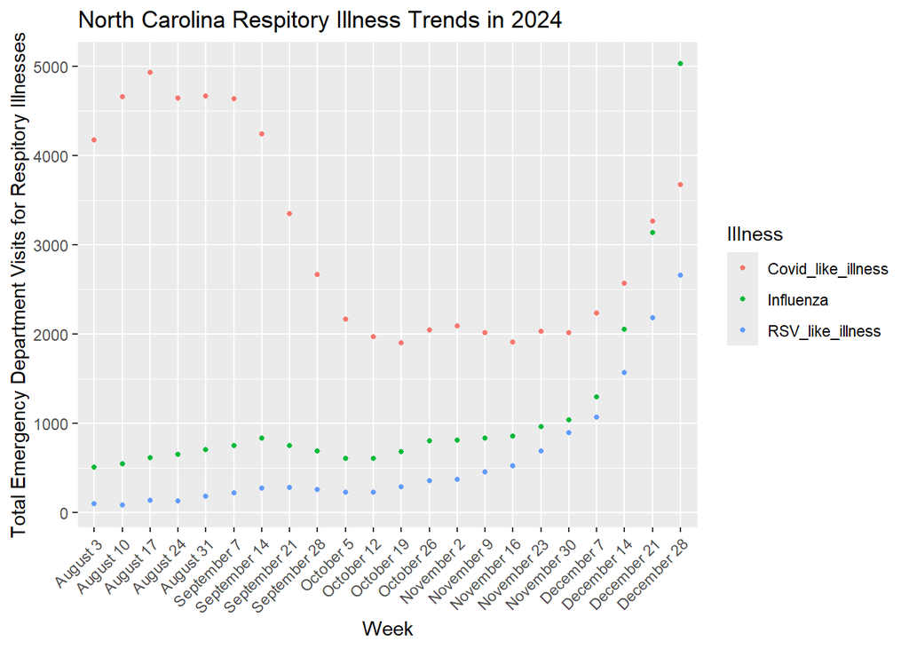

```r
nc_pivot <- nc %>%
  pivot_longer(2:4,
               names_to = "Illness",
               values_to = "Count") %>%
  select(-total)



(helene_by_illness <- ggplot(data = nc_pivot, aes(x = Date, y = Count, color = Illness))+
  geom_point(size = 1, na.rm = T)+
  theme(axis.text.x = element_text(angle = 45, hjust=1))+
  labs(x = "Week",
       y = "Total Emergency Department Visits for Respitory Illnesses",
       title = "North Carolina Respitory Illness Trends in 2024"))
```

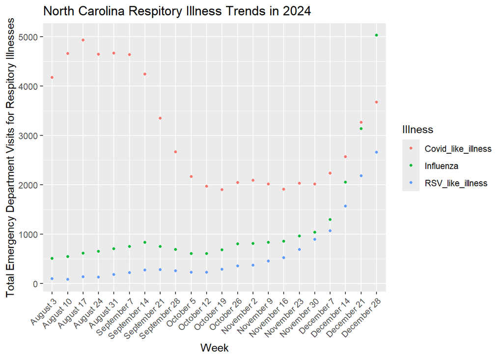

```r
helene_by_illness
```

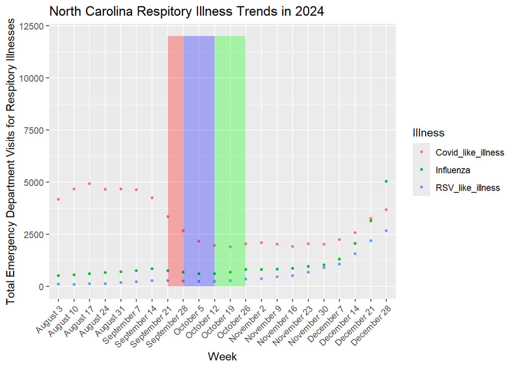

```r
helene_by_illness + annotate("rect", xmin = "September 21", xmax = "September 28", ymin = 0, ymax = 12000,
             alpha = 0.3, fill = "red") +
  annotate("rect", xmin = "September 28", xmax = "October 12", ymin = 0, ymax = 12000,
             alpha = 0.3, fill = "blue")+
  annotate("rect", xmin = "October 12", xmax = "October 26", ymin = 0, ymax = 12000,
             alpha = 0.3, fill = "green")
```

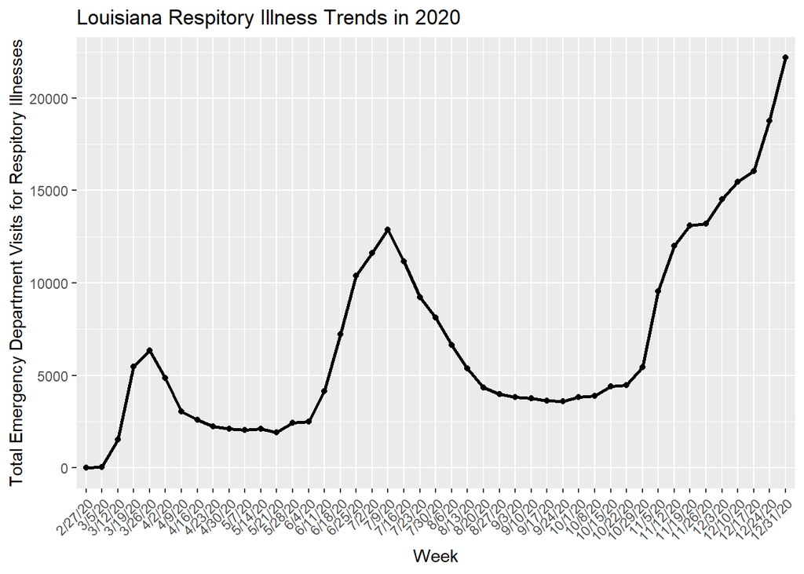

```r
LA <- read_csv(here("data/CSV_LA_COVID_TESTBYWEEK_TRACT_PUBLICUSE.csv"))

LA$Date_start_week <- as.character(LA$Date_start_week)
LA$Date_start_week <- factor(LA$Date_start_week, levels=unique(LA$Date_start_week))


LA <- LA %>%
  filter(str_ends(Date_start_week, "/20")) #%>%
  #filter(!str_starts(Date_start_week, "1")) %>%
  # filter(!str_starts(Date_start_week, "2")) %>%
  # filter(!str_starts(Date_start_week, "3")) %>%
  # filter(!str_starts(Date_start_week, "4")) %>%
  # filter(!str_starts(Date_start_week, "5")) %>%
  # select(-2,-3,-6,-7,-8)


LA<- LA %>%
  group_by(Date_start_week) %>%
  summarise(Count_total = sum(Weekly_Case_Count))



LA_graph <- ggplot(data = LA, aes(x = Date_start_week, y = Count_total))+
  geom_line(linewidth = 1, na.rm = T, aes(group=1))+
  geom_point()+
  theme(axis.text.x = element_text(angle = 45, hjust=1))+
  labs(x = "Week",
       y = "Total Emergency Department Visits for Respitory Illnesses",
       title = "Louisiana Respitory Illness Trends in 2020")

LA_graph
```

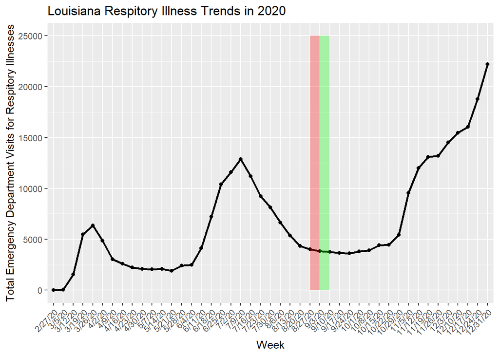

```r
LA_graph_annotated <- LA_graph + annotate("rect", xmin = "8/27/20", xmax = "9/3/20", ymin = 0, ymax = 25000,
             alpha = 0.3, fill = "red") +
  annotate("rect", xmin = "9/3/20", xmax = "9/10/20", ymin = 0, ymax = 25000,
             alpha = 0.3, fill = "green")


LA_graph_annotated
```

### How much do natural disasters affect the U.S. economy?

```r
losses <- read_csv(here("data/lnd_full_clean_2024-12-31.csv"))

losses <- losses %>%
  mutate(
    begin_date = as.Date(begin_date),
    year = year(begin_date)
  )

selected_losses <- losses %>%
  filter(event_type %in% c("Hurricane", "Flood", "Tornado", "Wildfire"))
```

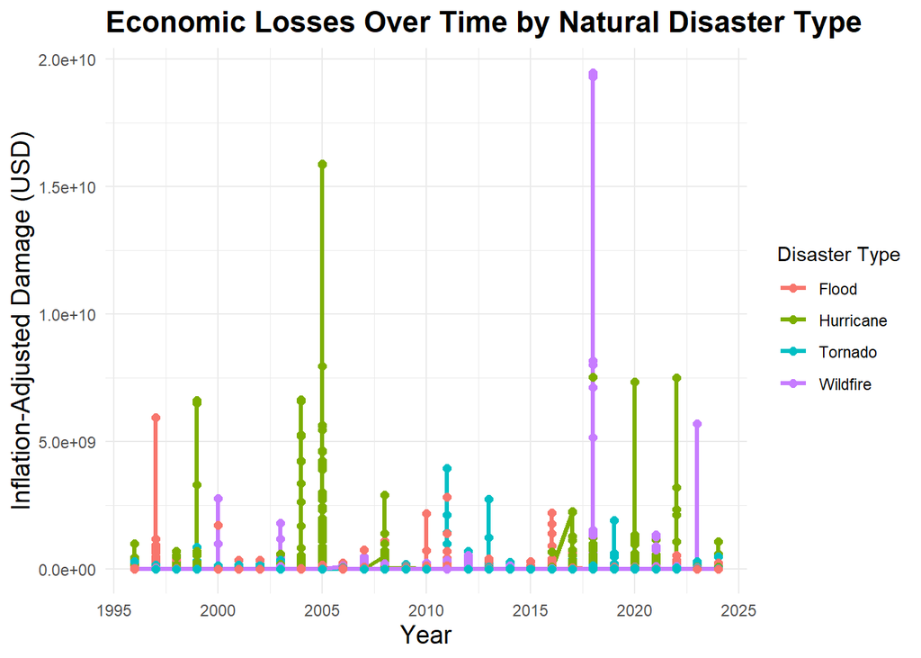

```r
ggplot(selected_losses, aes(x = year,
                            y = damages_total_adj,
                            color = event_type,
                            group = event_type)) +
  geom_line(linewidth = 1.1) +
  geom_point(size = 2) +
  labs(
    title = "Economic Losses Over Time by Natural Disaster Type",
    x = "Year",
    y = "Inflation-Adjusted Damage (USD)",
    color = "Disaster Type"
  ) +
  theme_minimal() +
  theme(
    plot.title = element_text(face = "bold", size = 16),
    axis.title = element_text(size = 14)
  )
```

### Which U.S. regions experience the highest economic losses from natural disasters?

```r
options(tigris_use_cache = TRUE)

counties <- counties(cb = TRUE, year = 2021)

losses <- losses %>%
  mutate(fips = str_pad(fips, width = 5, side = "left", pad = "0")) %>%
  filter(damages_total_adj > 0)

major_types <- c(
  "Flood", "Flash Flood", "Hurricane", "Tropical Storm",
  "Storm Surge/Tide", "Tornado", "Wildfire", "High Wind",
  "Winter Storm", "Thunderstorm Wind"
)

losses_major <- losses %>%
  filter(event_type %in% major_types)

county_damage <- losses_major %>%
  group_by(fips) %>%
  summarize(total_damage = sum(damages_total_adj, na.rm = TRUE))

map_data <- counties %>%
  left_join(county_damage, by = c("GEOID" = "fips"))

map_data$total_damage[is.na(map_data$total_damage)] <- 0
```

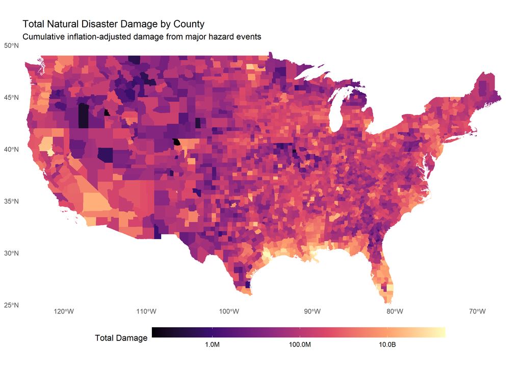

```r
ggplot(map_data) +
  geom_sf(aes(fill = total_damage), color = NA) +
  scale_fill_viridis_c(
    option = "A",
    trans = "log10",
    labels = scales::label_number(
      accuracy = 0.1,
      scale_cut = scales::cut_short_scale()
    )
  ) +
  labs(
    title = "Total Natural Disaster Damage by County",
    subtitle = "Cumulative inflation-adjusted damage from major hazard events",
    fill = "Total Damage"
  ) +
  coord_sf(
    xlim = c(-125, -65),
    ylim = c(25, 50),
    expand = FALSE
  ) +
  theme_minimal(base_size = 16) +
  theme(
    legend.position = "bottom",
    legend.key.width = unit(4, "cm"),
    legend.key.height = unit(0.7, "cm"),
    panel.grid = element_blank()
  )
```

Our county-level graph of cumulative damages from natural hazards suggests that economic impacts are regionally concentrated by severities of damages. Damage is consistent along the Gulf Coast (Texas, Louisiana, Mississippi, Alabama, Florida) and to the region as a whole in the Southeast due to seasonality of hurricanes or long-term, major flooding events. We also observe consistent damages along the Atlantic Coast, then into the Northeast, again consistent with coastal storm characteristics that could re-expose the area to damages over time. On the West Coast, specifically California, the cumulative impacts from wildfires and other large scale hazards show economic impacts in an affect we see with floods. Finally, to the contrary, the inland areas of the Midwest and northern interior states show a significantly lower cumulative damage overall and only a few areas show substantial damages due to weather. Overall, there is a clear geographic divide in that coastal areas see a significantly concentrated economic risk, mostly in the regions bordering the Gulf and Atlantic Oceans, where inland areas tend to have lower high-damage events.

### What disasters cause the most deaths?

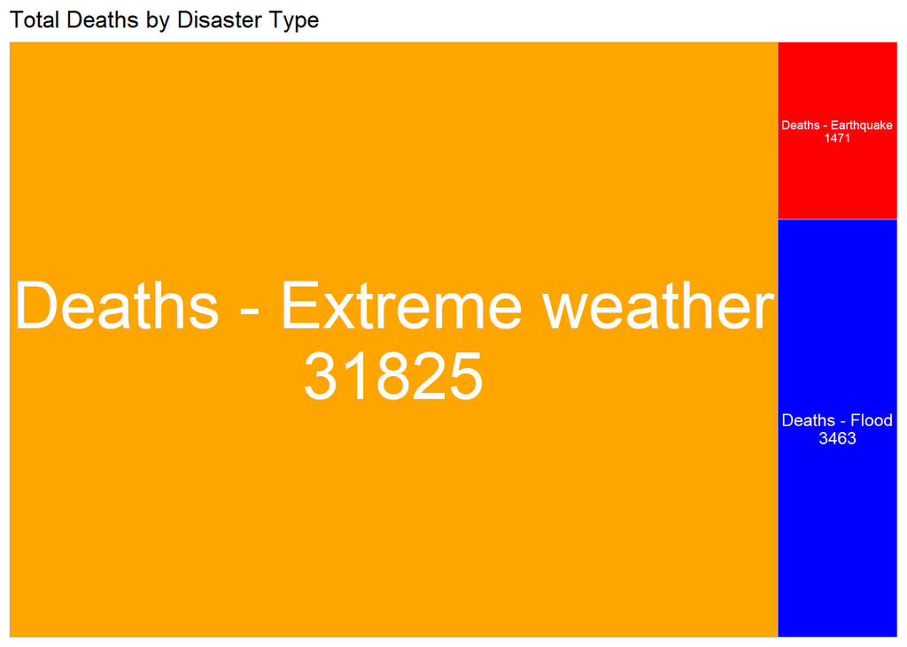

```r
# import data
deaths <- read_csv(here("data/number-of-deaths-by-disaster.csv"))

deaths_usa <- deaths %>%
  filter(Entity == "United States") %>%
  select(Year,
         `Deaths - Flood`,
         `Deaths - Earthquake`,
         `Deaths - Extreme weather`)

long_data <- deaths_usa %>%
  pivot_longer(cols = -Year, names_to = "Disaster", values_to = "Deaths") %>%
  mutate(Deaths = ifelse(is.na(Deaths), 0, Deaths))

total_data <- long_data %>%
  group_by(Disaster) %>%
  summarise(Total_Deaths = sum(Deaths))

ggplot(total_data, aes(
  area = Total_Deaths,
  fill = Disaster,
  label = paste0(Disaster, "\n", Total_Deaths)
)) +
  geom_treemap() +
  geom_treemap_text(
    colour = "white",
    place = "centre",
    grow = TRUE
  ) +
  scale_fill_manual(values = c(
    "Deaths - Flood" = "blue",
    "Deaths - Earthquake" = "red",
    "Deaths - Extreme weather" = "orange"
  )) +
  labs(title = "Total Deaths by Disaster Type") +
  theme(legend.position = "none")
```

### What disasters cause the highest rates of homelessness?

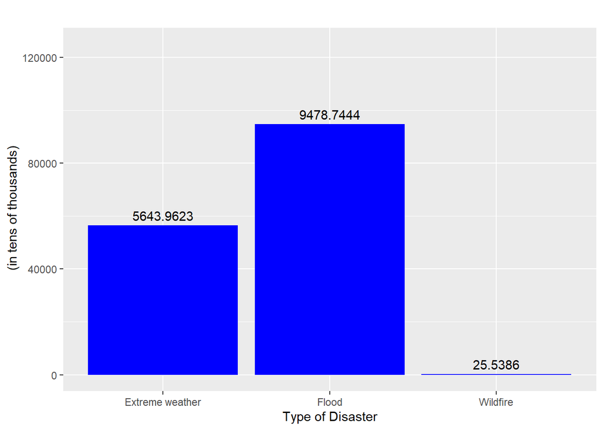

```r
homeless <- read_csv(here("data/number-homeless-from-natural-disasters.csv"))

three_types <- homeless %>%
  group_by(Entity) %>%
  summarise(total_homeless = sum(Homeless, na.rm = TRUE)) %>%
  filter(Entity %in% c("Extreme weather", "Flood", "Wildfire"))

all_disasters <- homeless %>%
  group_by(Entity) %>%
  summarise(total_homeless = sum(Homeless, na.rm = TRUE)) %>%
  filter(Entity == "All disasters")

ggplot(data = three_types,
       aes(x = Entity, y = total_homeless / 1000))+
  geom_bar(stat = "identity", fill = "blue") +
  geom_text(aes(label = total_homeless/10000, vjust = -0.5)) +
  scale_y_continuous(limits = c(0, 125000)) +
  labs(title = "",
       x = "Type of Disaster",
       y = " (in tens of thousands)")
```

The relationship we are investigating in this graph is the relationship between homelessness and natural disasters. Specifically, we are investigating how much three natural disasters (Extreme weather, floods, and wildfires) cause people to become homeless, and comparing the amounts of the three to determine which type causes the most cases of homelessness. We can determine from the graph that floods cause the most homelessness (likely due to water damage), with extreme weather coming in second (likely due to structural damage) and wildfires the lowest of the three (likely due to wildfires typically occurring farther from populous areas).

## Member Contributions

### Kaya Williams

- How do rates of respiratory symptoms change after natural disasters? charts
- Worked on progress report file

### Akillesh Suresh

- Which U.S. regions experience the highest economic losses from natural disasters? chart
- How much do natural disasters affect the U.S. economy? chart
- Worked on progress report file

### Alyssa Girard

- What disasters cause the most deaths? chart
- What disasters cause the highest rates of homelessness? chart
- Worked on progress report file